# NFL 2020 Week 17

MAJ Daniel Baller

8/27/2019

## Instructor Group Predictions

This Week's Predictions

Week 17

| Game | Prediction | Winner | Correct | Correct Votes | Correct Percent |
| --- | --- | --- | --- | --- | --- |
| 1 | Dallas Cowboys | New York Giants | No | 4 | 0.4 |
| 2 | Baltimore Ravens | Baltimore Ravens | Yes | 10 | 1.0 |
| 3 | Tampa Bay Buccaneers | Tampa Bay Buccaneers | Yes | 10 | 1.0 |
| 4 | Buffalo Bills | Buffalo Bills | Yes | 10 | 1.0 |
| 5 | Minnesota Vikings | Minnesota Vikings | Yes | 10 | 1.0 |
| 6 | Pittsburgh Steelers | Cleveland Browns | No | 4 | 0.4 |
| 7 | New England Patriots | New England Patriots | Yes | 8 | 0.8 |
| 8 | Tennessee Titans | Tennessee Titans | Yes | 10 | 1.0 |
| 9 | Seattle Seahawks | Seattle Seahawks | Yes | 10 | 1.0 |
| 10 | Green Bay Packers | Green Bay Packers | Yes | 7 | 0.7 |
| 11 | Los Angeles Rams | Los Angeles Rams | Yes | 9 | 0.9 |
| 12 | Indianapolis Colts | Indianapolis Colts | Yes | 10 | 1.0 |
| 13 | Kansas City Chiefs | Los Angeles Chargers | No | 1 | 0.1 |
| 14 | New Orleans Saints | New Orleans Saints | Yes | 9 | 0.9 |
| 15 | Las Vegas Raiders | Las Vegas Raiders | Yes | 9 | 0.9 |
| 16 | Washington Football Team | Washington Football Team | Yes | 6 | 0.6 |

Our win percentage for the week is 0.8125

Our season win percentage so far is 0.6706

Games picked this season 252

Correct Games this season 169

predictions this week

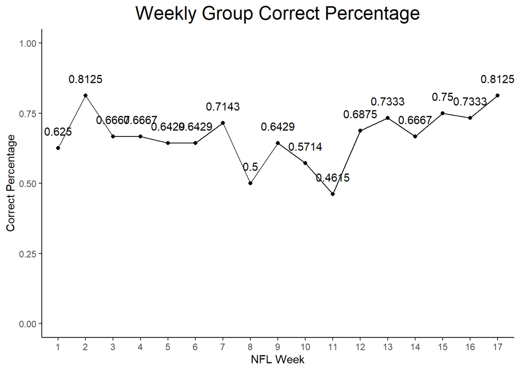

## Individual Predictions

Individual Results

Week 17

Name

Weekly # Correct

Percent

Weeks Picked

Season Percent

Adj Season Percent

Season Trend

Week 1

Week 2

Week 3

Week 4

Week 5

Week 6

Week 7

Week 8

Week 9

Week 10

Week 11

Week 12

Week 13

Week 14

Week 15

Week 16

Week 17

Kevin Cummiskey

13

11

9

9

10

7

9

5

10

9

7

12

10

10

12

10

14

0.8750

17

0.6627

0.6627

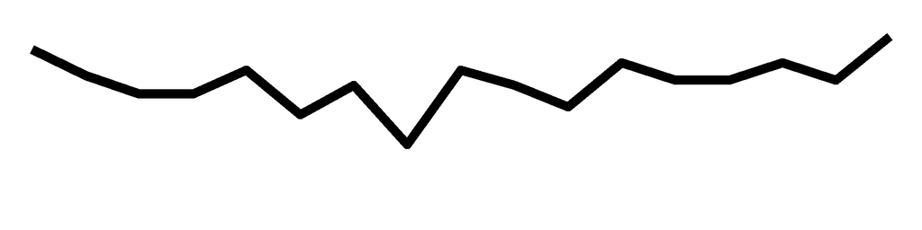

Tina Hartley

9

11

10

8

8

9

9

7

3

8

6

10

9

9

12

10

14

0.8750

17

0.6032

0.6032

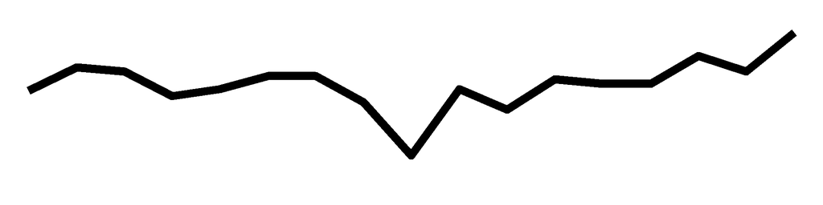

Gregory Minetos

9

14

10

12

8

8

12

7

10

7

7

11

9

9

12

8

13

0.8125

17

0.6587

0.6587

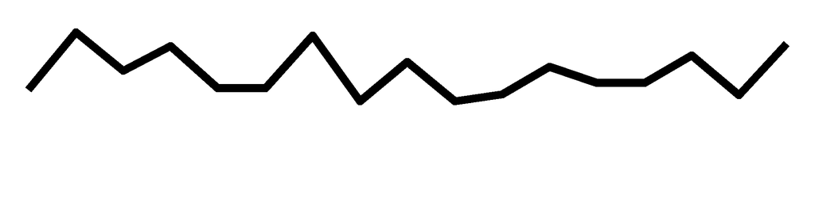

Gabriel Costa

9

12

6

9

10

7

9

7

10

10

9

NA

11

8

9

10

13

0.8125

16

0.6314

0.5943

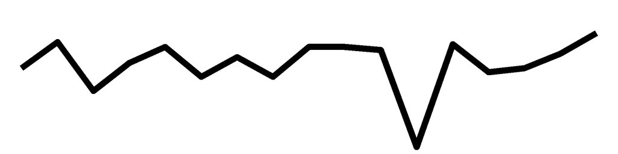

Frank Czerniakowski

7

13

10

9

8

6

9

6

11

5

9

11

9

12

NA

10

13

0.8125

16

0.6271

0.5902

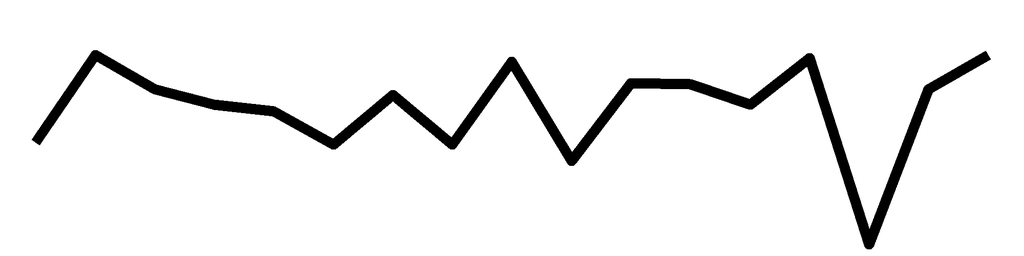

Blake Schwartz

10

9

10

10

10

9

9

6

5

8

7

9

11

10

11

11

13

0.8125

17

0.6270

0.6270

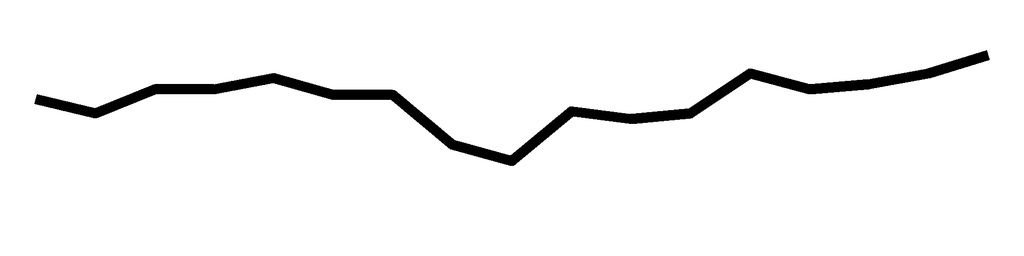

Eric Swenson

4

8

10

9

9

8

9

8

7

8

8

10

11

9

12

11

13

0.8125

17

0.6111

0.6111

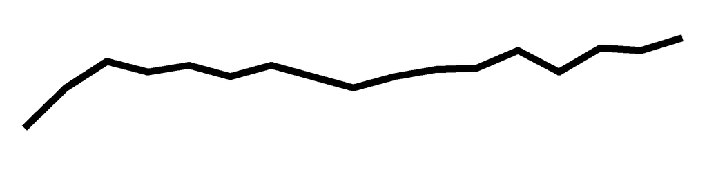

Josephine Cammack

9

11

12

10

9

9

11

7

6

8

NA

9

12

11

12

NA

12

0.7500

15

0.6607

0.5830

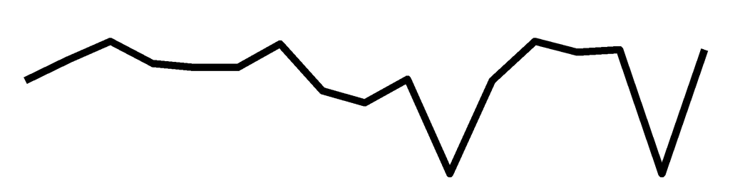

Daniel Baller

11

10

10

9

9

5

8

9

11

10

8

11

11

11

10

11

12

0.7500

17

0.6587

0.6587

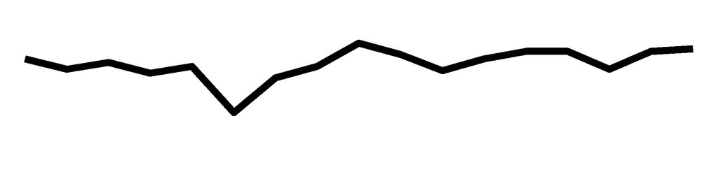

Shane Clark

10

14

9

9

9

9

10

NA

11

7

7

12

10

11

NA

NA

10

0.6250

14

0.6667

0.5490

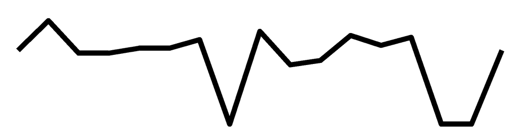

James Starling

15

12

9

12

10

NA

11

8

10

10

6

11

11

7

10

14

NA

0.0000

15

0.7027

0.6200

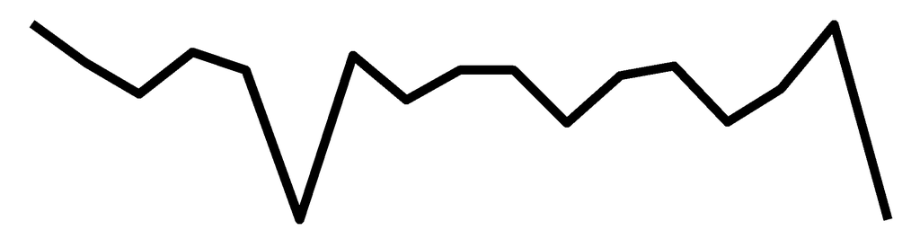

Daniel Richardson

13

11

10

10

8

NA

8

NA

NA

NA

NA

NA

NA

NA

NA

NA

NA

0.0000

6

0.6667

0.2353

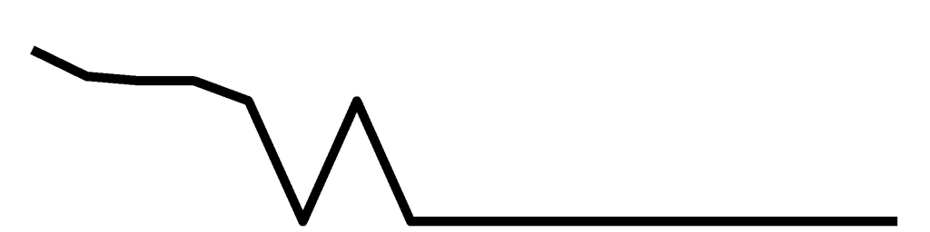

James Pleuss

9

12

10

12

7

8

10

9

9

10

7

10

12

12

11

9

NA

0.0000

16

0.6653

0.6262

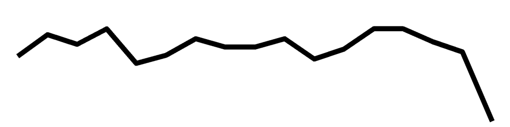

Michael Prokos

9

12

9

8

11

10

9

7

9

9

7

10

11

12

12

9

NA

0.0000

16

0.6525

0.6141

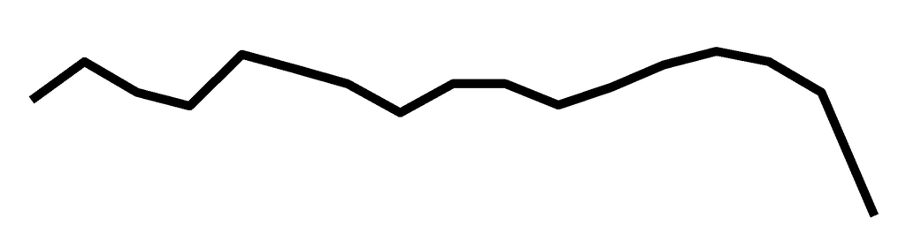

Margaret Wieczorek

11

14

9

9

8

NA

10

8

9

8

7

8

11

11

12

NA

NA

0.0000

14

0.6522

0.5371

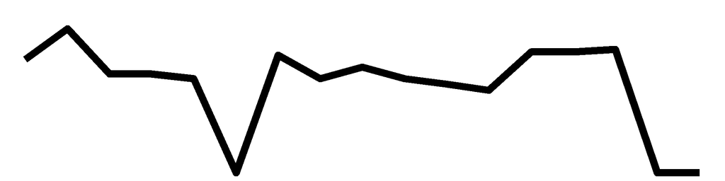

Travis Russell

11

8

8

11

10

10

10

8

NA

NA

7

NA

NA

NA

NA

NA

NA

0.0000

9

0.6336

0.3354

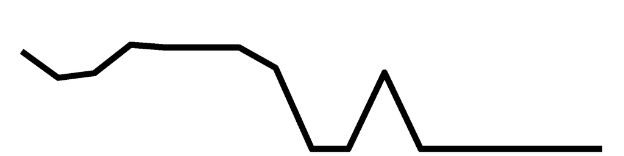

John Kearby

9

11

6

9

9

8

12

6

9

10

6

10

11

9

11

10

NA

0.0000

16

0.6186

0.5822

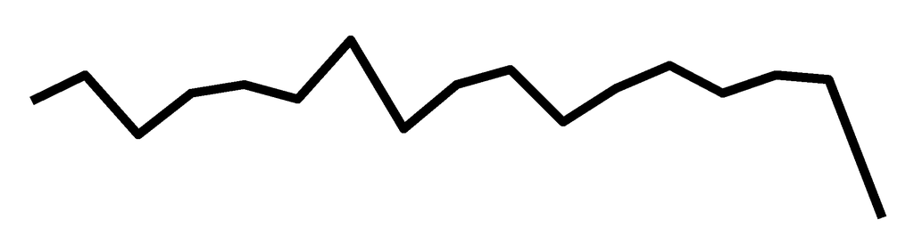

Nicholas Reisweber

9

10

10

8

10

7

8

8

10

9

6

14

9

8

9

11

NA

0.0000

16

0.6186

0.5822

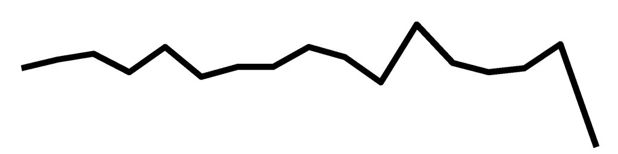

Welvin Lucero

9

11

9

10

NA

NA

11

8

NA

8

5

NA

NA

10

NA

NA

NA

0.0000

9

0.6136

0.3248

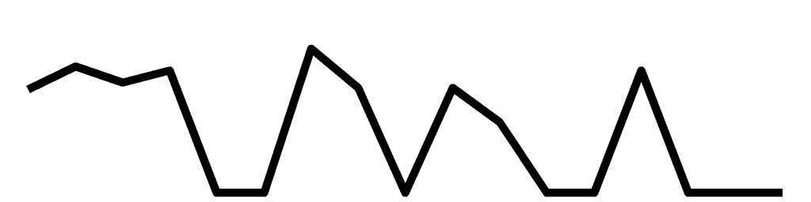

Kevin Quigley

8

8

9

10

10

8

8

6

8

7

9

10

NA

NA

11

9

NA

0.0000

14

0.5874

0.4837

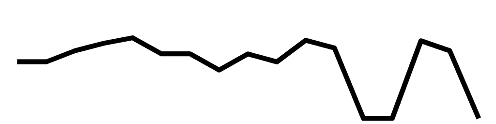

Andrew Lee

9

10

8

NA

NA

NA

NA

NA

NA

NA

NA

NA

NA

NA

NA

NA

NA

0.0000

3

0.5745

0.1014

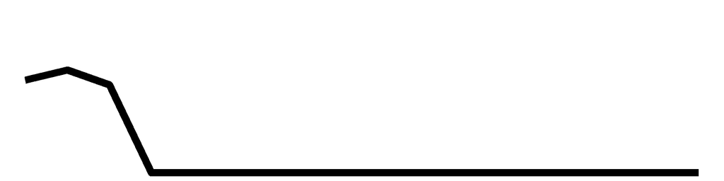

Timothy Moore

10

11

8

9

7

9

7

7

7

NA

NA

NA

9

10

8

NA

NA

0.0000

12

0.5730

0.4045

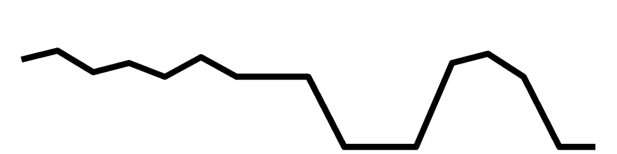

Congrats Kevin Cummiskey for having the best picks this week, with a correct percentage of 0.875, Congrats Tina Hartley for having the best picks this week, with a correct percentage of 0.875

| Name | Week 1 | Week 2 | Week 3 | Week 4 | Week 5 | Week 6 | Week 7 | Week 8 | Week 9 | Week 10 | Week 11 | Week 12 | Week 13 | Week 14 | Week 15 | Week 16 | Week 17 | Percent | Weeks Picked | Season Percent | Adj Season Percent | Season Trend |
| --- | --- | --- | --- | --- | --- | --- | --- | --- | --- | --- | --- | --- | --- | --- | --- | --- | --- | --- | --- | --- | --- | --- |
| Kevin Cummiskey | 13 | 11 | 9 | 9 | 10 | 7 | 9 | 5 | 10 | 9 | 7 | 12 | 10 | 10 | 12 | 10 | 14 | 0.8750 | 17 | 0.6627 | 0.6627 |  |
| Tina Hartley | 9 | 11 | 10 | 8 | 8 | 9 | 9 | 7 | 3 | 8 | 6 | 10 | 9 | 9 | 12 | 10 | 14 | 0.8750 | 17 | 0.6032 | 0.6032 |  |
| Gregory Minetos | 9 | 14 | 10 | 12 | 8 | 8 | 12 | 7 | 10 | 7 | 7 | 11 | 9 | 9 | 12 | 8 | 13 | 0.8125 | 17 | 0.6587 | 0.6587 |  |
| Gabriel Costa | 9 | 12 | 6 | 9 | 10 | 7 | 9 | 7 | 10 | 10 | 9 | NA | 11 | 8 | 9 | 10 | 13 | 0.8125 | 16 | 0.6314 | 0.5943 |  |
| Frank Czerniakowski | 7 | 13 | 10 | 9 | 8 | 6 | 9 | 6 | 11 | 5 | 9 | 11 | 9 | 12 | NA | 10 | 13 | 0.8125 | 16 | 0.6271 | 0.5902 |  |
| Blake Schwartz | 10 | 9 | 10 | 10 | 10 | 9 | 9 | 6 | 5 | 8 | 7 | 9 | 11 | 10 | 11 | 11 | 13 | 0.8125 | 17 | 0.627 | 0.627 |  |
| Eric Swenson | 4 | 8 | 10 | 9 | 9 | 8 | 9 | 8 | 7 | 8 | 8 | 10 | 11 | 9 | 12 | 11 | 13 | 0.8125 | 17 | 0.6111 | 0.6111 |  |
| Josephine Cammack | 9 | 11 | 12 | 10 | 9 | 9 | 11 | 7 | 6 | 8 | NA | 9 | 12 | 11 | 12 | NA | 12 | 0.7500 | 15 | 0.6607 | 0.583 |  |
| Daniel Baller | 11 | 10 | 10 | 9 | 9 | 5 | 8 | 9 | 11 | 10 | 8 | 11 | 11 | 11 | 10 | 11 | 12 | 0.7500 | 17 | 0.6587 | 0.6587 |  |
| Shane Clark | 10 | 14 | 9 | 9 | 9 | 9 | 10 | NA | 11 | 7 | 7 | 12 | 10 | 11 | NA | NA | 10 | 0.6250 | 14 | 0.6667 | 0.549 |  |
| James Starling | 15 | 12 | 9 | 12 | 10 | NA | 11 | 8 | 10 | 10 | 6 | 11 | 11 | 7 | 10 | 14 | NA | 0.0000 | 15 | 0.7027 | 0.62 |  |
| Daniel Richardson | 13 | 11 | 10 | 10 | 8 | NA | 8 | NA | NA | NA | NA | NA | NA | NA | NA | NA | NA | 0.0000 | 6 | 0.6667 | 0.2353 |  |
| James Pleuss | 9 | 12 | 10 | 12 | 7 | 8 | 10 | 9 | 9 | 10 | 7 | 10 | 12 | 12 | 11 | 9 | NA | 0.0000 | 16 | 0.6653 | 0.6262 |  |
| Michael Prokos | 9 | 12 | 9 | 8 | 11 | 10 | 9 | 7 | 9 | 9 | 7 | 10 | 11 | 12 | 12 | 9 | NA | 0.0000 | 16 | 0.6525 | 0.6141 |  |
| Margaret Wieczorek | 11 | 14 | 9 | 9 | 8 | NA | 10 | 8 | 9 | 8 | 7 | 8 | 11 | 11 | 12 | NA | NA | 0.0000 | 14 | 0.6522 | 0.5371 |  |
| Travis Russell | 11 | 8 | 8 | 11 | 10 | 10 | 10 | 8 | NA | NA | 7 | NA | NA | NA | NA | NA | NA | 0.0000 | 9 | 0.6336 | 0.3354 |  |
| John Kearby | 9 | 11 | 6 | 9 | 9 | 8 | 12 | 6 | 9 | 10 | 6 | 10 | 11 | 9 | 11 | 10 | NA | 0.0000 | 16 | 0.6186 | 0.5822 |  |
| Nicholas Reisweber | 9 | 10 | 10 | 8 | 10 | 7 | 8 | 8 | 10 | 9 | 6 | 14 | 9 | 8 | 9 | 11 | NA | 0.0000 | 16 | 0.6186 | 0.5822 |  |
| Welvin Lucero | 9 | 11 | 9 | 10 | NA | NA | 11 | 8 | NA | 8 | 5 | NA | NA | 10 | NA | NA | NA | 0.0000 | 9 | 0.6136 | 0.3248 |  |
| Kevin Quigley | 8 | 8 | 9 | 10 | 10 | 8 | 8 | 6 | 8 | 7 | 9 | 10 | NA | NA | 11 | 9 | NA | 0.0000 | 14 | 0.5874 | 0.4837 |  |
| Andrew Lee | 9 | 10 | 8 | NA | NA | NA | NA | NA | NA | NA | NA | NA | NA | NA | NA | NA | NA | 0.0000 | 3 | 0.5745 | 0.1014 |  |
| Timothy Moore | 10 | 11 | 8 | 9 | 7 | 9 | 7 | 7 | 7 | NA | NA | NA | 9 | 10 | 8 | NA | NA | 0.0000 | 12 | 0.573 | 0.4045 |  |

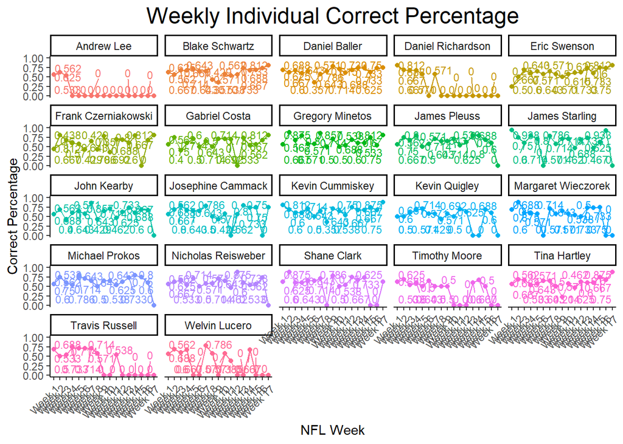

## MA206 Group Predictions

This Week's MA206 Predictions

Week 17

| Game | Prediction | Winner | Correct | Correct Votes | Correct Percent |
| --- | --- | --- | --- | --- | --- |
| 1 | Dallas Cowboys | New York Giants | No | 0 | 0.00 |
| 2 | Baltimore Ravens | Baltimore Ravens | Yes | 4 | 1.00 |
| 3 | Tampa Bay Buccaneers | Tampa Bay Buccaneers | Yes | 4 | 1.00 |
| 4 | Buffalo Bills | Buffalo Bills | Yes | 3 | 0.75 |
| 5 | Minnesota Vikings | Minnesota Vikings | Yes | 4 | 1.00 |
| 6 | Pittsburgh Steelers | Cleveland Browns | No | 0 | 0.00 |
| 7 | New England Patriots | New England Patriots | Yes | 4 | 1.00 |
| 8 | Tennessee Titans | Tennessee Titans | Yes | 4 | 1.00 |
| 9 | Seattle Seahawks | Seattle Seahawks | Yes | 4 | 1.00 |
| 10 | Green Bay Packers | Green Bay Packers | Yes | 4 | 1.00 |
| 11 | Los Angeles Rams | Los Angeles Rams | Yes | 3 | 0.75 |
| 12 | Indianapolis Colts | Indianapolis Colts | Yes | 4 | 1.00 |
| 13 | Kansas City Chiefs | Los Angeles Chargers | No | 1 | 0.25 |
| 14 | New Orleans Saints | New Orleans Saints | Yes | 4 | 1.00 |
| 15 | Las Vegas Raiders | Las Vegas Raiders | Yes | 4 | 1.00 |
| 16 | Washington Football Team | Washington Football Team | Yes | 3 | 0.75 |

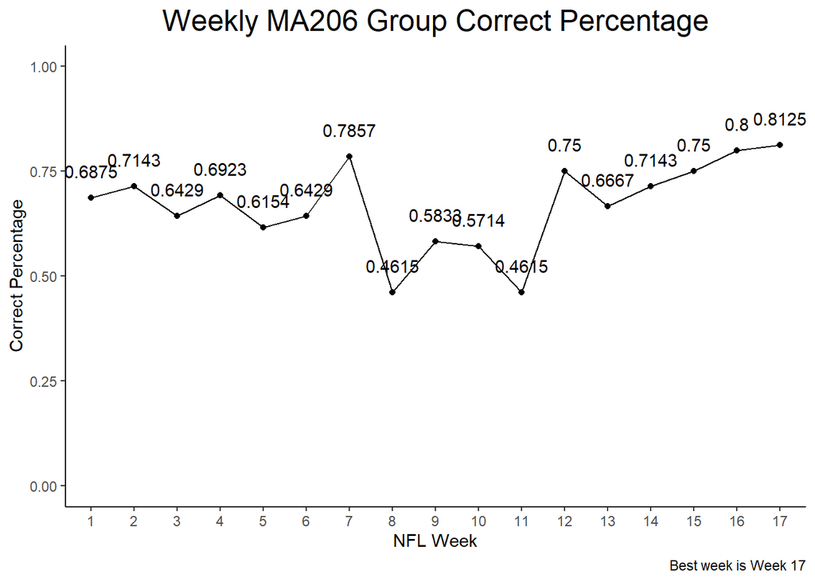